# FairML: Software Packages in R: some examples

Duc-Anh Nguyen

2024-02-25

### Libraries used

```r
library(dplyr)
library(tidyr)
```

```r
library(ggplot2)
library(caret)
library(glmnet)
library(ranger)
library(gbm)
library(DALEX)
library(fairness)
library(fairmodels)
library(mlr3)
library(mlr3fairness)
library(mlr3learners)
library(mlr3tuning)
library(fairml)
library(mlr3pipelines)
```

# mlr3fairness

```r
set.seed(84)
task <- tsk("compas")
# train a random forest model
learner = lrn("classif.rpart", cp = 0.005)
# debiasing with reweighting
learner_rw = as_learner(po("reweighing_wts") %>>% learner)
# Here we combine the PipeOp with a Learner to automate the preprocessing.
# Then we run a small benchmark
grd = benchmark_grid(list(task), list(learner, learner_rw), rsmp("cv", folds=3))
bmr = benchmark(grd)
```

```
## INFO  [06:15:15.874] [mlr3] Running benchmark with 6 resampling iterations
## INFO  [06:15:15.947] [mlr3] Applying learner 'classif.rpart' on task 'compas' (iter 1/3)
## INFO  [06:15:16.000] [mlr3] Applying learner 'classif.rpart' on task 'compas' (iter 2/3)
## INFO  [06:15:16.081] [mlr3] Applying learner 'classif.rpart' on task 'compas' (iter 3/3)
## INFO  [06:15:16.116] [mlr3] Applying learner 'reweighing_wts.classif.rpart' on task 'compas' (iter 1/3)
## INFO  [06:15:16.568] [mlr3] Applying learner 'reweighing_wts.classif.rpart' on task 'compas' (iter 2/3)
## INFO  [06:15:16.712] [mlr3] Applying learner 'reweighing_wts.classif.rpart' on task 'compas' (iter 3/3)
## INFO  [06:15:16.851] [mlr3] Finished benchmark
```

```r
bmr$aggregate(msrs(c("fairness.tpr", "fairness.acc")))
```

```
##       nr task_id                   learner_id resampling_id iters fairness.tpr
##    <int>  <char>                       <char>        <char> <int>        <num>
## 1:     1  compas                classif.rpart            cv     3    0.0320706
## 2:     2  compas reweighing_wts.classif.rpart            cv     3    0.0320706
##    fairness.acc
##           <num>
## 1:   0.01306067
## 2:   0.01306067
## Hidden columns: resample_result
```

The results show no difference between the two approaches. This might mean that our data is not unbalanced, and we need to try other approaches to enhance fairness in model.

# fairmodels

Move onto the second package fairmodels, we will use the same data as above, then train another random forest with the package ranger. Then with the same idea above, we try to mitigate bias by appplying again the method of reweighting.

```r
set.seed(84)
# using the same data as above
df <- task$data()
# the data compas from mlr3fairness also has this is_recid variable, which show if
# one ever commit recidivism (compared to two_year_recid, which only considered the
# next two year after crime). Here we do not need it for the modeling.
df <- select(df, -is_recid)
# Using fairmodels we need to define the protected attribute for the assessing
protected <- df$race

# we apply reweight, a built-in method in the package
weights <- reweight(protected = protected, y = as.numeric(df$two_year_recid) - 1)
# training random forest
rf_compas <- ranger(two_year_recid ~., data = df, probability = TRUE)
y_numeric <- as.numeric(df$two_year_recid) - 1
# based on DALEX, here we need to create an explainer
rf_explainer <- explain(rf_compas, data = df[,-1], y = y_numeric, colorize = FALSE)
```

```
## Preparation of a new explainer is initiated
##   -> model label       :  ranger  (  default  )
##   -> data              :  6172  rows  10  cols
##   -> target variable   :  6172  values
##   -> predict function  :  yhat.ranger  will be used (  default  )
##   -> predicted values  :  No value for predict function target column. (  default  )
##   -> model_info        :  package ranger , ver. 0.15.1 , task classification (  default  )
##   -> predicted values  :  numerical, min =  0.02190261 , mean =  0.4551974 , max =  0.97024
##   -> residual function :  difference between y and yhat (  default  )
##   -> residuals         :  numerical, min =  -0.7914761 , mean =  -7.750224e-05 , max =  0.8899671
##   A new explainer has been created!
```

```r
# then we can use funciton fairness_check, which help quickly check bias with with
# some of the most popular fairness metrics (group fairness)
fobject <- fairness_check(rf_explainer,   # explainer
                          protected = df$race, # protected variable as factor
                          privileged = "Caucasian", #level in protected variable, potentially more privileged
                          cutoff = 0.5,    # cutoff - optional, default = 0.5
                          colorize = FALSE)
```

```
## Creating fairness classification object
## -> Privileged subgroup       : character ( Ok  )
## -> Protected variable        : factor ( Ok  )
## -> Cutoff values for explainers  : 0.5 ( for all subgroups )
## -> Fairness objects      : 0 objects
## -> Checking explainers       : 1 in total (  compatible  )
## -> Metric calculation        : 8/13 metrics calculated for all models ( 5 NA created )
##  Fairness object created succesfully
```

```r
# debiasing with reweighting, here we rebuild another random forest
rf_compas_w <- ranger(two_year_recid ~., data = df, case.weights = weights, probability = TRUE)
rf_explainer_w <- explain(rf_compas_w,
                           data = df[,-1],
                           y = y_numeric,
                           label = "rf_weighted",
                           verbose = FALSE)
fobject <- fairness_check(fobject, rf_explainer_w, verbose = FALSE)
# now we can compare the two models
print(fobject, colorize = FALSE)
```

```
##
## Fairness check for models: rf_weighted, ranger
##
## rf_weighted passes 3/5 metrics
## Total loss :  4.277317
##
## ranger passes 2/5 metrics
## Total loss :  5.430707
```

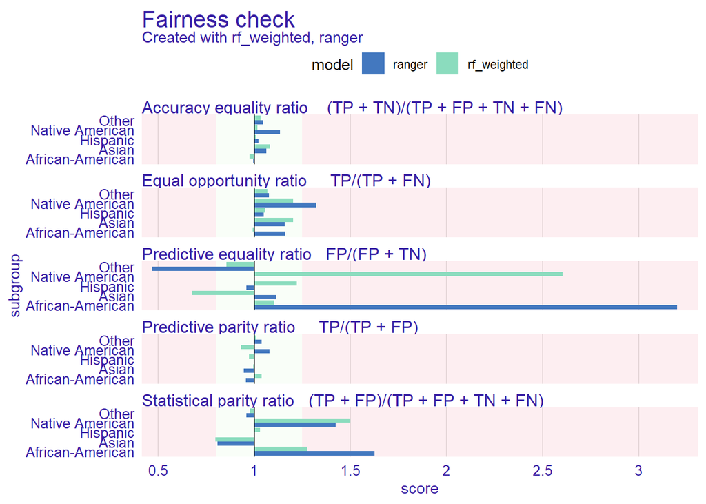

```r
plot(fobject)
```

The ranger model frequently exceeds established fairness thresholds, which can be adjusted using the epsilon parameter. Visual indicators, such as bars reaching into the left red zone, denote bias against particular unprivileged subgroups.

On the other hand, bars extending into the right red zone indicate bias favoring privileged subgroups, with the Caucasian group often serving as the baseline (marked as 1) in all metrics.

These metrics express the ratios between unprivileged and privileged subgroups (e.g., African American to Caucasian). By default, they follow the 80% rule stipulated by the Code of Federal Regulations (1978), which, for instance, implies that women should be granted credit at a minimum rate of 80% relative to men. This framework aims to measure the fairness of treatment and mistreatment among various subgroups.

With the plot we could see that the equal opportunity ratio is getting fairer in the reweighted model.

# fairml

Here we showcase how to learn a basic model provided in the package fairml: FGRRM (fair generalized ridge regression model). We also fit a logistic regression model to compare.

```r
data("compas", package = "fairml")
# extracting the response variable (r), the sensitive attributes (s) and the predictors (p)
r = compas[, "two_year_recid"]
s = compas[, c("sex", "race")]
p = compas[, setdiff(names(compas), c("two_year_recid", "sex", "race"))]

# fgrrm() is the extension of frrm() to generalized linear models, currently implementing linear
# (family = "gaussian") and logistic (family = "binomial") regressions. fgrrm() is equivalent to
# frrm() with family = "gaussian".

# Notice: The definition of fairness are identical between frrm() and fgrrm(),
# by default sp-komiyama (statistical parity). Other options: "eo-komiyama" (Equalised Odds)
# or "if-berk" (Individual fairness).
m =  fgrrm(response = r, sensitive = s, predictors = p,  family = "binomial", unfairness = 0.05)
summary(m)
```

```
##
## Fair Linear Regression Model
##
## Method: Fair Generalized Ridge Regression
##
## Call:
## fgrrm(response = r, predictors = p, sensitive = s, unfairness = 0.05,
##     family = "binomial")
##
## Coefficients:
##         (Intercept)              sexMale            raceAsian
##            -0.21035              0.15375             -0.32929
##       raceCaucasian         raceHispanic  raceNative.American
##            -0.12802             -0.14229              0.03101
##           raceOther                  age        juv_fel_count
##            -0.14536             -0.01300              0.05202
##        decile_score       juv_misd_count      juv_other_count
##             0.14307             -0.01250              0.10942
##      v_decile_score         priors_count            c_jail_in
##             0.05564              0.09408            -17.60960
##          c_jail_out       c_offense_date       screening_date
##            26.21397              7.21737             12.93023
##          in_custody          out_custody
##             8.59839             11.39737
##
## Ridge penalty (sensitive attributes): 0.5797 (predictors): 0
## Log-likelihood: -3191
## Komiyama's R^2 (statistical parity): 0.05 with bound: 0.05
```

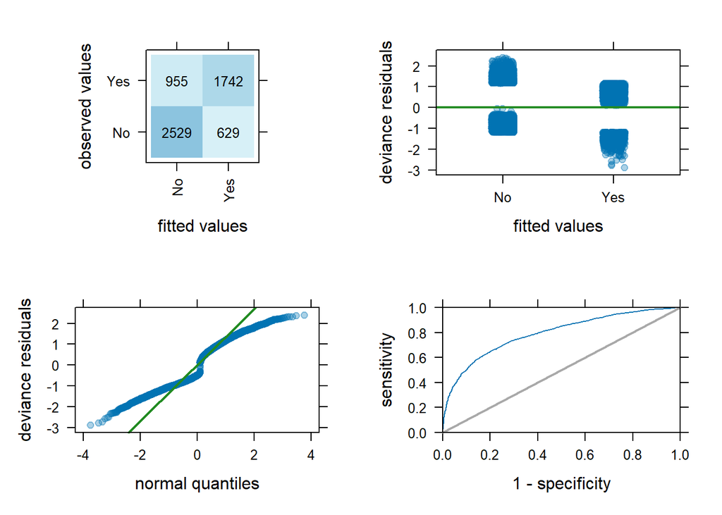

```r
# m = nclm(response = r, sensitive = s, predictors = p, unfairness = 0.05)
# summary(m)
# m = frrm(response = r, sensitive = s, predictors = p, unfairness = 0.05)
# summary(m)

# Is this model a good fit for the data? The diagnostic plots generated by
plot(m, support = TRUE)
```

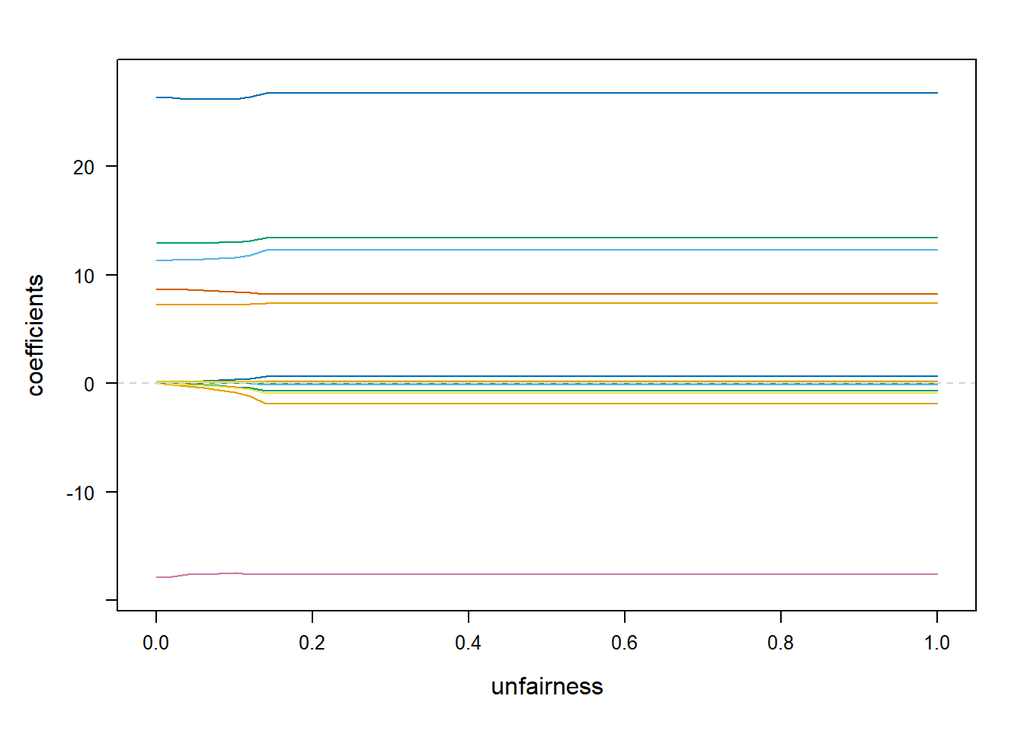

```r
# The package fairml apparently also offers function for visualising fairness in
# its own way.
fairness.profile.plot(response = r, sensitive = s, predictors = p, model = "fgrrm",
                      type = "coefficients", model.args = list(family = "binomial"))
```

```r
# fit logit models
model <- glm(two_year_recid ~ .,
              data   = compas,
              family = binomial(link = 'logit'))
```

The profile plots created by function fairness.profile.plot() for regression coefficients as a function of the fairness constraint across all levels of the response variable provide a visual exploration of how introducing fairness considerations into a model affects its parameters. These plots are particularly useful in regression analysis when one want to understand the impact of enforcing fairness constraints on the estimated coefficients for different groups or outcomes in their model.

# fairness

Focuses on measuring and visualising one fairness metric at a time, the package fairness will be used now to illustrate the performance of the two models trained with the package fairml above.

```r
compas$prob_1 <- predict(m, new.predictors = p, new.sensitive = s, type = "response")
compas$prob_2 <- predict(model, compas, type = 'response')

# Here we choose predictive rate parity as the fairness metric to be compared
res1 <- pred_rate_parity(data         = compas,
                         outcome      = 'two_year_recid',
                         outcome_base = 'No',
                         group        = 'race',
                         probs        = 'prob_1',
                         cutoff       = 0.5,
                         base         = 'Caucasian')
res1$Metric
```

```
##                           Caucasian African-American      Asian    Hispanic
## Precision                 0.6879064        0.7805447  0.7142857   0.6432432
## Predictive Rate Parity    1.0000000        1.1346671  1.0383473   0.9350738
## Group size             2055.0000000     2941.0000000 28.0000000 501.0000000
##                        Native American       Other
## Precision                    0.8333333   0.6806723
## Predictive Rate Parity       1.2114052   0.9894839
## Group size                  14.0000000 316.0000000
```

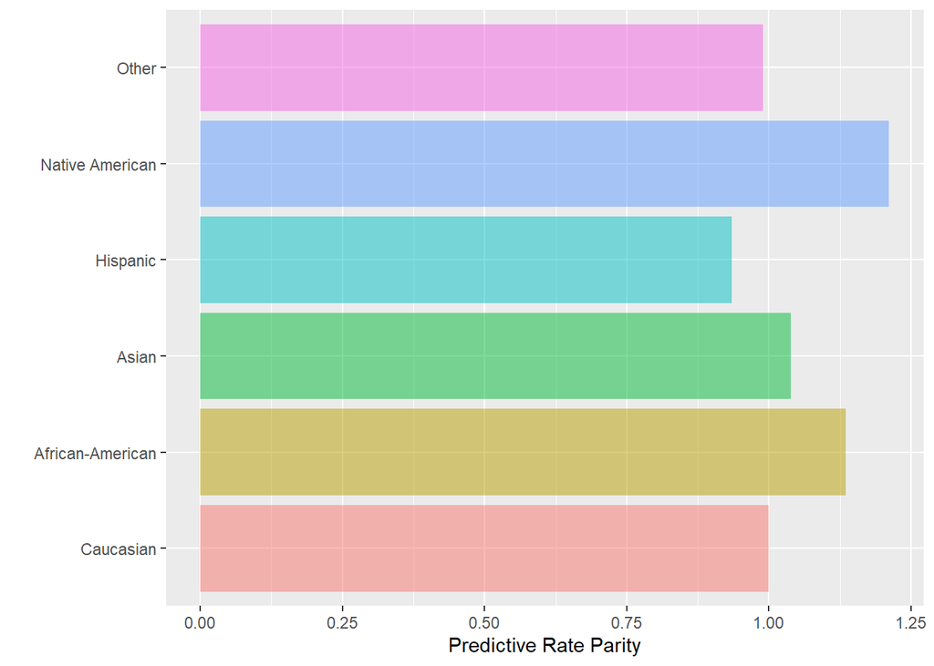

```r
res1$Metric_plot
```

```r
res2 <- pred_rate_parity(data         = compas,
                         outcome      = 'two_year_recid',
                         outcome_base = 'No',
                         group        = 'race',
                         probs        = 'prob_2',
                         cutoff       = 0.5,
                         base         = 'Caucasian')
res2$Metric
```

```
##                           Caucasian African-American     Asian   Hispanic
## Precision                 0.7193252        0.7456197  1.000000   0.750000
## Predictive Rate Parity    1.0000000        1.0365545  1.390192   1.042644
## Group size             2055.0000000     2941.0000000 28.000000 501.000000
##                        Native American      Other
## Precision                    0.8333333   0.800000
## Predictive Rate Parity       1.1584932   1.112154
## Group size                  14.0000000 316.000000
```

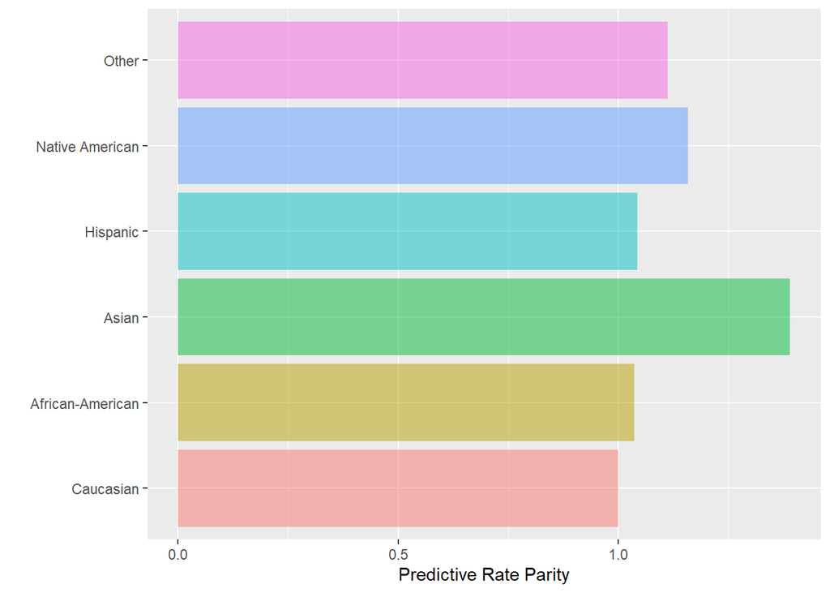

```r
res2$Metric_plot
```

In an ideal scenario, predictive rate parities would all be equal to one, signifying that the precision across all groups matches that of the base group.

In reality, however, these values tend to vary. A parity greater than one suggests that the precision within a particular group is comparatively higher than in the base group, while a parity less than one indicates reduced precision.

Significant variations in these parity values serve as an indicator that the model’s performance is not uniform across different groups, pointing to potential biases in how the model processes and predicts outcomes for diverse subsets of data. This variability underscores the importance of examining and adjusting model parameters or employing fairness-enhancing techniques to ensure equitable model performance across all groups.